# Assignment 7: Visualization - Some aspects of ggplot2

*How to do it?*:

- Open the Rmarkdown file of this assignment (link) in Rstudio.
- Right under each **question**, insert a code chunk (you can use the hotkey `Ctrl + Alt + I` to add a code chunk) and code the solution for the question.
- `Knit` the rmarkdown file (hotkey: `Ctrl + Alt + K`) to export an html.
- Publish the html file to your Githiub Page.

*Submission*: Submit the link on Github of the assignment to Canvas

### I. Questions on Your Selected Data

Use the data of your own. Produce the following types of plots and comment on each plot. Plots should be meaningful. If you use the data we used in class, make sure the plots are not the same as the ones in the slides. All plots should have title, caption, appropriate labels on x and y-axis.

```r
library(tidyverse)
```

```r
library(ggplot2)
df7 <-read_csv("C:/Users/student/Desktop/Data Mining 460/ncaaVB.csv")
```

1. Make a plot using `face_wrap` by one categorical variable (`face_wrap(~variable1)`)

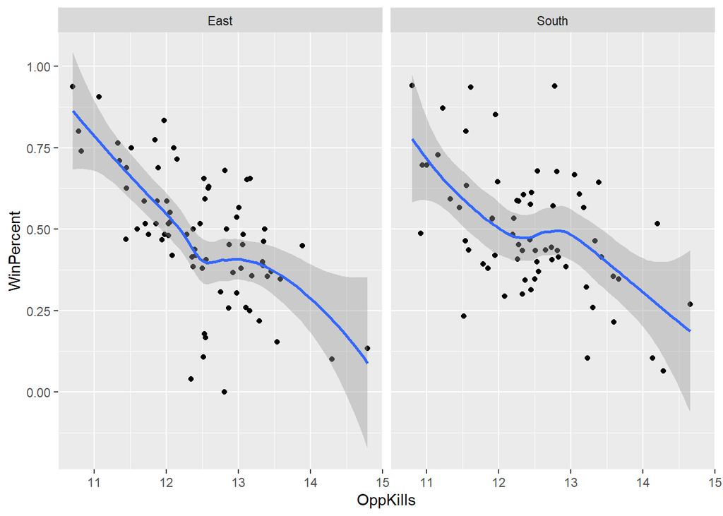

```r
df7 %>% filter(Region=='East'|Region=='South') %>% ggplot()+ geom_point(mapping=aes(x=OppKills, y=WinPercent)) + geom_smooth(mapping=aes(x=OppKills, y=WinPercent)) + facet_wrap(~Region)
```

```r
#In both the East and South regions, Winning percentage seems to be negatively correlated with opponent kills.  This makes sense becuase teams that give up more kills will be more likley to lose games, and geography should have no bearing on this.
```

2. Make a plot using `face_wrap` by two categorical variables (`face_wrap(variable1~variable2)`)

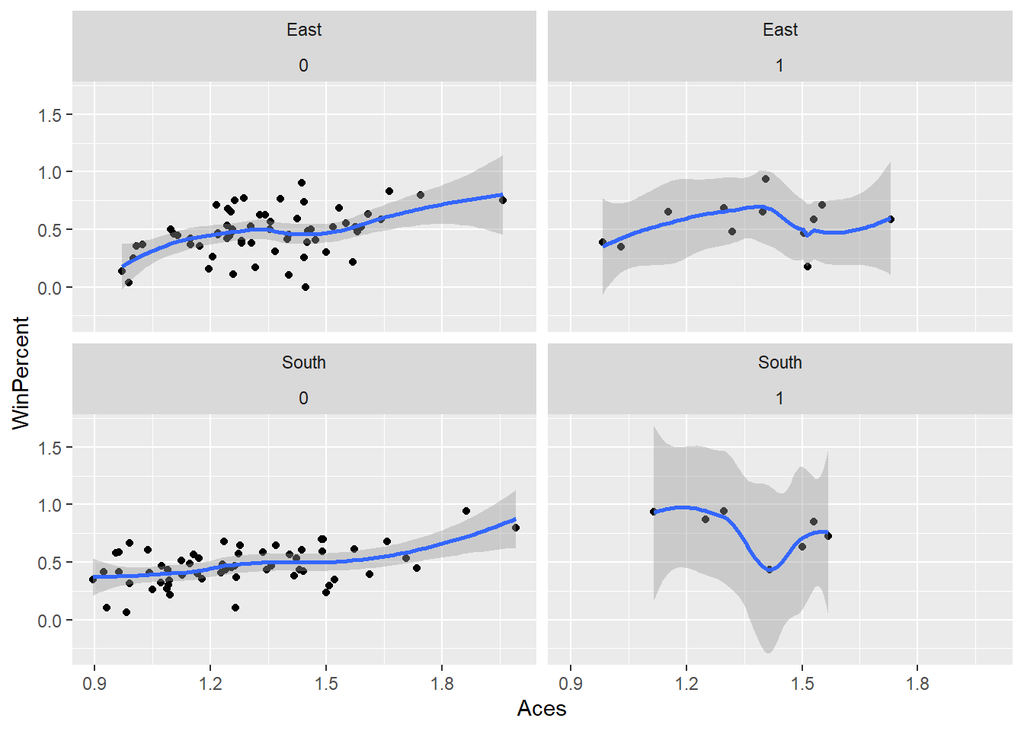

```r
df7 %>% filter(Region=='East'|Region=='South') %>%  ggplot()+ geom_point(mapping=aes(x=Aces, y=WinPercent)) + geom_smooth(mapping=aes(x=Aces, y=WinPercent)) + facet_wrap(Region~Tourney2018)
```

```r
#In general, there appears to be a bit more variation among teams that were in the tournament last year (1) than those who did not make playoffs (0).  For non-playoff teams, aces seem to improve winning percentage, while the curved fits for playoff teams have dips up and down, and it does not appear aces have a large impact on win percentage there.
```

3. Make a plot using `position ='jitter'`.

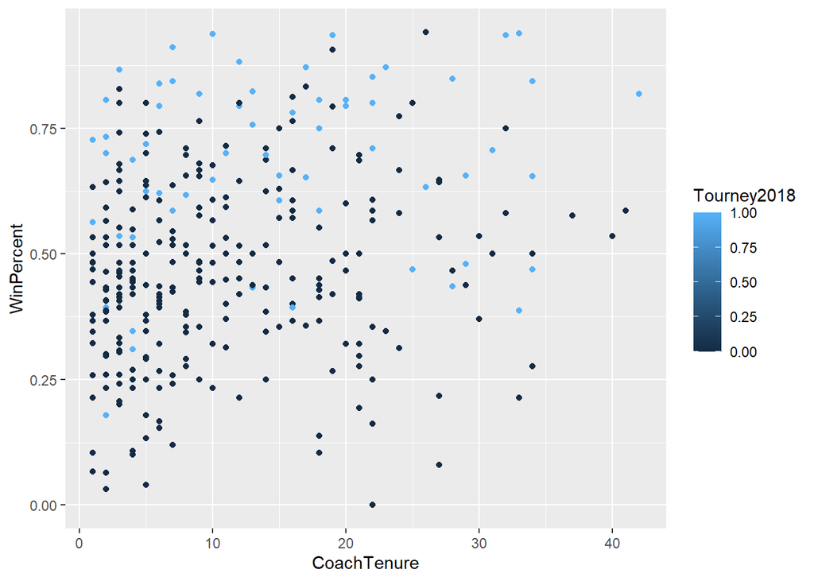

```r
df7 %>% ggplot()+ geom_point(mapping=aes(x=CoachTenure, y=WinPercent, color=Tourney2018))
```

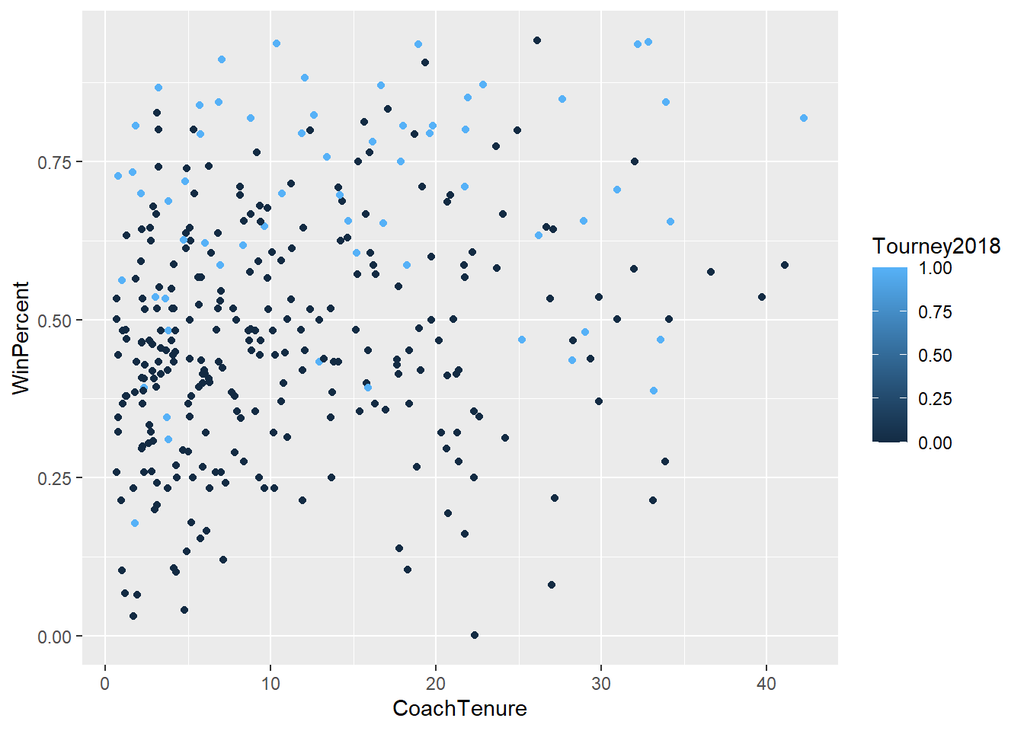

```r
df7 %>% ggplot()+ geom_point(mapping=aes(x=CoachTenure, y=WinPercent, color=Tourney2018), position='jitter')
```

```r
#Jitter function helps so that all points can be seen.  It appears that coaches who have been around for a while tend to have teams that perform slightly better.  Also, the lightblue dots represent teams who made the playoffs in previous years - those teams tend to do better than average in the following season.
```

4. Make a plot using `position ='dodge'`.

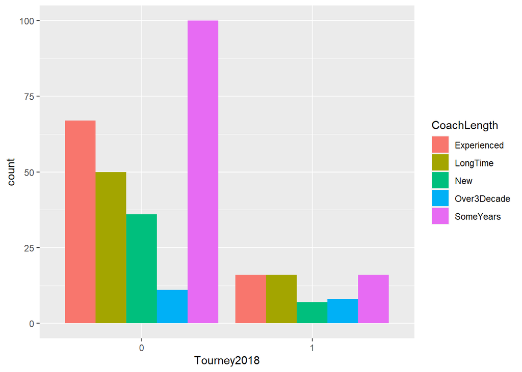

```r
df7$Tourney2018 <- as.factor(df7$Tourney2018 )
#to make it binary category instead of continuous
df7 %>% ggplot()+geom_bar(mapping=aes(x=Tourney2018, fill=CoachLength),
           position = 'dodge')
```